# Supervised Clustering of Personality Traits Dataset

Josephine Kaminaga, Aarti Garaye

2025-12-02

In this section of the vignette, we will demonstrate how to apply two common supervised clustering methods to the personality traits dataset. These two methods are partitioning around medoids (PAM) and constrained k-means clustering with background knowledge (COP K-means).

PAM can be implemented with the `cluster` package, while COP K-means can be implemented with `conclust`. (Note: this package was removed from CRAN, and we are using a downloaded & archived version of the `ckmeans()` function that is used to perform COP K-means clustering). The PAM method partitions data around medoids, which are data points that are most representative of the clustered structure of the data. Quoting from the `cluster` package description: “the goal is to find *k* representative objects which minimize the sum of their dissimilarities of the observations to their closest representative object”, where the ‘representative object’ is a medoid. The COP K-means algorithm implements constraints on which data points must and must not be in the same cluster as each other. Through both of these methods, we can conduct supervised clustering.

```r
library(tidyverse)
library(cluster)

personality <- read.csv("../data/raw/personality_synthetic_dataset.csv")
source("ckmeans.R")
```

## PAM

The workhorse function for PAM is the `pam()` function from the `cluster` package. This function requires an `x` argument, which is the data matrix or dataframe to perform clustering on, and a `k` argument which represents the number of clusters that we are looking for. There are a number of other optional arguments which enable flexibility for this function. In the function call below, we are specifying `diss = FALSE` to ensure that the function does not think `x` is a dissimilarity matrix, and `metric = "euclidean"` due to the multidimensional nature of our personality dataset. While some implementations of PAM require that the user manually finds medoids, this implementation conducts the search for a suitable initial set of medoids by itself.

```r
personality <- personality |>
  mutate(
    personality_type = as.factor(personality_type)
  )

pam_clustered <- pam(personality, 3, diss = FALSE,
    metric = "euclidean"
    )
```

The results of the PAM model can be visualized by calling `plot()` upon the PAM model. Below, we can see that when `plot()` is called, we obtain a PCA-reminiscent plot of the personality data along two components that together explain 43.92% of the variability in the data. PAM has identified the three distinct clusters that stand out in this representation. We also obtain a numeric description of the clusters’ sizes and numeric widths in the component space.

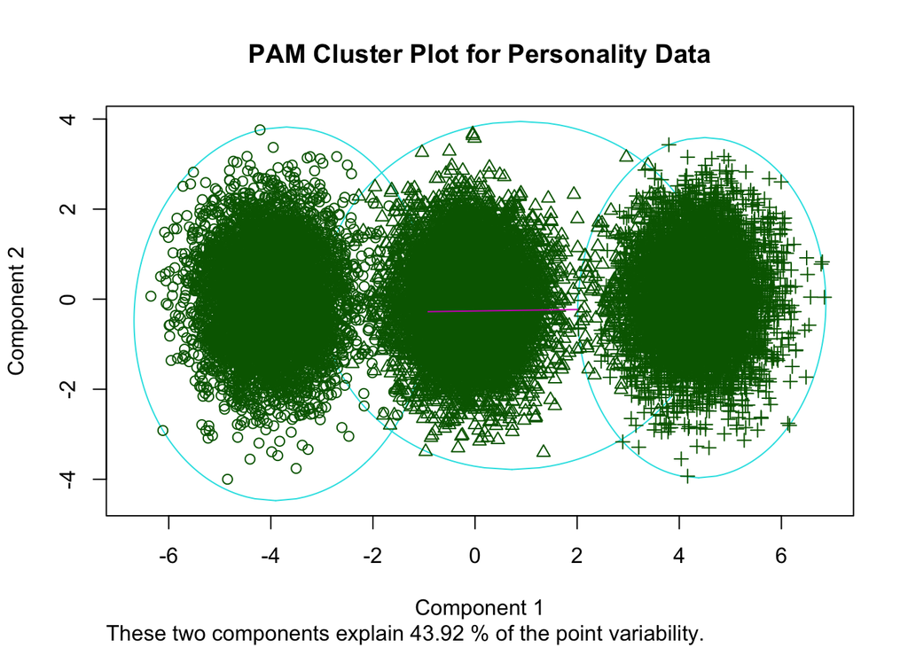

[figure not shown]

```r
plot(pam_clustered, main = "PAM Cluster Plot for Personality Data")
```

We can obtain further results by inspecting the fitted elements of the PAM model directly. As seen below, the PAM model returns information about the medoids, their locations, the clusters and their sizes, and some other miscellaneous attributes of the data.

```r
names(pam_clustered)
```

```
##  [1] "medoids"    "id.med"     "clustering" "objective"  "isolation"
##  [6] "clusinfo"   "silinfo"    "diss"       "call"       "data"
```

The most important information from the PAM model can be found by accessing the `medoids`, `clusinfo`, and `silinfo` attributes. The `medoids` attribute contains the values of each medoid along each variable in the data, as seen below.

```r
pam_clustered$medoids
```

```
##      personality_type social_energy alone_time_preference talkativeness
## [1,]                2      7.406811              2.235440      9.172372
## [2,]                1      3.494744              5.745153      4.652769
## [3,]                3      3.259338              7.464871      2.523655
##      deep_reflection group_comfort party_liking listening_skill  empathy
## [1,]        3.586678      8.306333     7.659353        5.861117 5.148295
## [2,]        5.495603      5.978168     4.755904        7.818847 5.663815
## [3,]        6.616111      3.141268     1.895573        9.173012 8.737643
##      creativity organization leadership risk_taking public_speaking_comfort
## [1,]   5.595678     4.315666   7.531658    7.437853                7.520732
## [2,]   5.527898     5.926737   6.248520    4.459779                4.925115
## [3,]   5.431702     7.840322   3.756620    2.292241                4.042761
##      curiosity routine_preference excitement_seeking friendliness
## [1,]  6.050193           3.539609           7.586667     8.451355
## [2,]  6.853544           6.161454           5.350742     7.716442
## [3,]  6.139455           7.827334           2.089178     5.868511
##      emotional_stability planning spontaneity adventurousness reading_habit
## [1,]            6.036026 4.976859    7.643141        8.090848      5.917936
## [2,]            5.550136 5.919260    5.620713        5.225287      6.056601
## [3,]            5.552662 7.301337    2.091976        2.811703      7.884244
##      sports_interest online_social_usage travel_desire gadget_usage
## [1,]        4.516458            8.984372      7.646414     6.560955
## [2,]        5.566365            6.376277      6.345300     3.622792
## [3,]        3.726055            6.308437      2.827615     4.359290
##      work_style_collaborative decision_speed stress_handling
## [1,]                 8.552186       6.468760        7.047821
## [2,]                 5.263834       4.452687        4.720935
## [3,]                 4.881269       2.908636        5.666559
```

The `clusinfo` attribute contains information about the size and dissimilarities of each identified cluster, while the `silinfo` attribute describes the silhouette of the PAM model (a measurement of cluster consistency) and contains multiple smaller attributes - `widths` has information about the designated cluster and silhouette width of each individual data point, `clus.avg.widths` has the average silhouette width of each identified cluster, and `avg.width` is the average width across all clusters. Since `widths` is quite the long attribute, we will skip that and show `clus.avg.widths` instead.

```r
pam_clustered$clusinfo
```

```
##      size max_diss  av_diss diameter separation
## [1,] 6916 13.91928 9.023962 19.20332   5.652021
## [2,] 6725 13.54176 9.105314 20.78441   5.495476
## [3,] 6359 12.96615 8.997817 19.17771   5.495476
```

```r
names(pam_clustered$silinfo)
```

```
## [1] "widths"          "clus.avg.widths" "avg.width"
```

```r
pam_clustered$silinfo$clus.avg.widths
```

```
## [1] 0.2394656 0.1648012 0.2349622
```

## Constrained K-Means

Constrained K-Means (COP K-Means) extends the traditional K-means algorithm by incorporating background knowledge in the form of pairwise constraints. Specifically, the algorithm uses:

- Must-link constraints: pairs of observations that must be assigned to the same cluster.
- Cannot-link constraints: pairs of observations that must not be assigned to the same cluster.

Unlike PAM, COP K-means requires the user to provide constraint sets. For our personality dataset with the outcome varaible as the `personality_type` we can construct constraints that mimic a realistic “semi-supervised” setting:

- Must-link: pick a few pairs of people with the same personality_type - these shouldn’t be separated by the clustering algorithm
- Cannot-Link: pick a few pairs of people with different personality_type - these shouldn’t be placed in the same cluster

This uses the ground truth only to form constraints, not as a variable in the clustering.

```r
set.seed(11302025)
# keep only numeric features
personality_num <- as.matrix(personality[ , -1])
```

We sample a handful of pairs to create small but meaningful constraint sets. These constraints are only for demonstration — in applied work, constraints come from domain experts.

1. Must Link pairs

```r
ext <- which(personality$personality_type == "Extrovert")
int <- which(personality$personality_type == "Introvert")
amb <- which(personality$personality_type == "Ambivert")

must_link_pairs <- rbind(
  sample(ext, 2),
  sample(int, 2),
  sample(amb, 2)
)
must_link_pairs
```

```
##       [,1]  [,2]
## [1,] 15700 11297
## [2,]  5028 12359
## [3,]   305  9178
```

2. Cannot-link

```r
cant_link_pairs <- rbind(
  c(sample(ext, 1), sample(int, 1)),
  c(sample(int, 1), sample(amb, 1)),
  c(sample(ext, 1), sample(amb, 1))
)
cant_link_pairs
```

```
##       [,1]  [,2]
## [1,] 11410 13567
## [2,] 14103  5754
## [3,] 17670 17401
```

Running COP K-Means

```r
ck_clusters <- ckmeans(
  data = personality_num,
  k = 3,
  mustLink = must_link_pairs,
  cantLink = cant_link_pairs,
  maxIter = 50
)

table(ck_clusters, personality$personality_type)
```

```
##
## ck_clusters Ambivert Extrovert Introvert
##           1       14         0      6559
##           2       17      6842         0
##           3     6542        15        11
```

Cluster 1: 6559 introverts, 14 ambiverts and 0 extroverts this is clearly the introvert cluster. So on and so forth. This is near-perfect recovery of personality type. COP-KMeans used only 6 constraints total: 3 must-link and 3 cannot-link. And still:

Extroverts is 99.7% correctly clustered Introverts is 100% correctly clustered Ambiverts is 99% correctly clustered

For an unsupervised method with almost no labels, this is exceptionally good. COP-KMeans is essentially “guided K-means,” so once each cluster gets “pulled” toward the correct region, the remaining points naturally follow.

Visualize

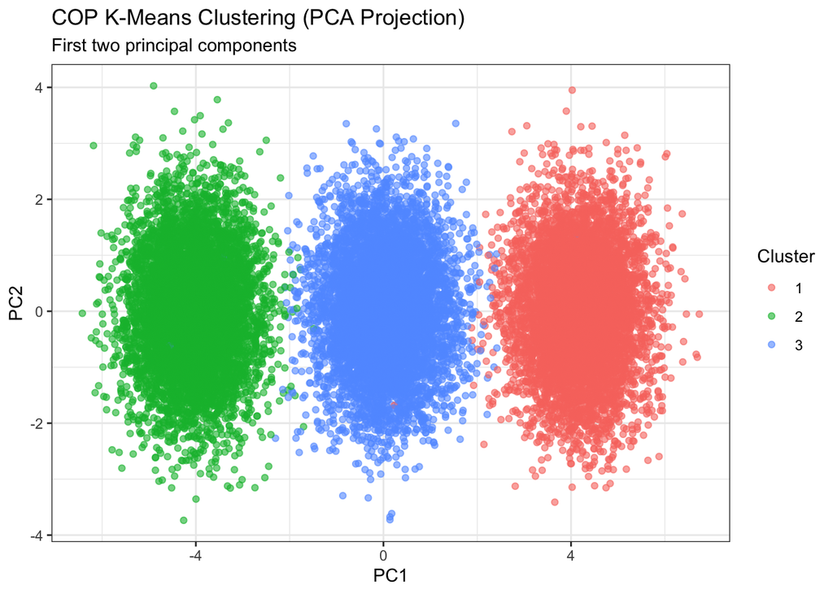

```r
# PCA for plotting
pca <- prcomp(personality_num, scale. = TRUE)
pca_df <- as.data.frame(pca$x[,1:2]) |>
  mutate(cluster = factor(ck_clusters))

ggplot(pca_df, aes(PC1, PC2, color = cluster)) +
  geom_point(alpha = 0.6) +
  labs(
    title = "COP K-Means Clustering (PCA Projection)",
    subtitle = "First two principal components",
    color = "Cluster"
  ) +
  theme_bw()
```

cluster size

```r
table(ck_clusters)
```

```
## ck_clusters
##    1    2    3
## 6573 6859 6568
```

Cluster centers (means of each)

```r
cluster_centers <- aggregate(personality_num,
                             by = list(cluster = ck_clusters),
                             FUN = mean)

cluster_centers
```

```
##   cluster social_energy alone_time_preference talkativeness deep_reflection
## 1       1      3.035966              7.960657      3.017551        7.916957
## 2       2      7.902112              3.007742      7.949479        4.031895
## 3       3      5.485354              5.502176      5.505369        6.011091
##   group_comfort party_liking listening_skill  empathy creativity organization
## 1      3.999220     2.049340        7.934069 6.974338   5.994112     6.981851
## 2      7.958821     7.961522        5.998676 6.005753   6.002411     4.993271
## 3      6.000488     4.982166        7.002657 6.490349   5.991249     5.987369
##   leadership risk_taking public_speaking_comfort curiosity routine_preference
## 1   4.013274    3.012814                3.009615  6.013120           6.970762
## 2   7.941271    6.941940                7.923933  6.973490           3.980442
## 3   6.023281    4.997074                5.498346  6.504377           5.472067
##   excitement_seeking friendliness emotional_stability planning spontaneity
## 1           3.016264     5.970622            6.039957 6.998589    4.004509
## 2           7.942070     7.925974            6.018240 5.022732    6.957832
## 3           5.522507     6.989204            5.989144 6.001130    5.459836
##   adventurousness reading_habit sports_interest online_social_usage
## 1        3.014832      7.926978        3.960899            5.022474
## 2        6.978804      3.981803        6.983112            7.931738
## 3        5.022872      5.998886        5.468581            6.479136
##   travel_desire gadget_usage work_style_collaborative decision_speed
## 1      4.002698     4.998792                 5.026432       3.969896
## 2      6.977356     6.987139                 7.932132       7.004334
## 3      5.482837     5.992085                 6.485153       5.509516
##   stress_handling
## 1        5.991588
## 2        5.965160
## 3        5.989937
```

We can see how these differ over the different personality types.

[figure not shown]

```r
dist_mat <- dist(personality_num)

sil <- silhouette(ck_clusters, dist_mat)

plot(sil, main = "Silhouette Plot for COP K-Means")
```

As we can see this is very similar to the PAM

```r
summary(sil)
```

```
## Silhouette of 20000 units in 3 clusters from silhouette.default(x = ck_clusters, dist = dist_mat) :
##  Cluster sizes and average silhouette widths:
##      6573      6859      6568
## 0.2284426 0.2320790 0.1709418
## Individual silhouette widths:
##    Min. 1st Qu.  Median    Mean 3rd Qu.    Max.
## -0.2878  0.1734  0.2122  0.2108  0.2533  0.3752
```

Cross Check with the truth

```r
table(ck_clusters, personality$personality_type)
```

```
##
## ck_clusters Ambivert Extrovert Introvert
##           1       14         0      6559
##           2       17      6842         0
##           3     6542        15        11
```